# Norges 1000 Rikeste - 2013

Turkuler

7/7/2020

For this exploratory analysis, I used a newspaper article on Dagens Næringsliv on the page with below url, which lists 1000 (actually 997 but I saw it after I downloaded the table) richest people in Norway in 2013 according to previous year tax documents

The libraries I need are htmltab for pulling the table from an html page, ggplot2 and pppubr for visualization and dplyr for data modification:

```r
library(htmltab)
library(ggplot2)
library(ggpubr)
library(dplyr)
```

I started with downloading html table to R and making some modifications to replace the column name of birth year (Født) with a Norwegian letter to all English characters and to numeric, commas to dots:

```r
url <- "https://www.dn.no/her-er-norges-1000-rikeste/1-1-2009497"
rikeste1000 <- htmltab(doc = url, which = "//th[text() = 'Navn']/ancestor::table")
rikeste1000 <- rename(rikeste1000, Fodt = Født) %>%
               mutate(Fodt = as.numeric(Fodt),
                      Inntekt = as.numeric(gsub(",",".", Inntekt)),
                      Skatt = as.numeric(gsub(",",".", Skatt)),
                      Formue = as.numeric(gsub(",",".", Formue)),
                      Bosted = as.factor(Bosted))
```

Checking the lookabouts of table:

```r
head(rikeste1000)
```

```
##                    Navn Fodt     Bosted Formue Inntekt Skatt
## 1             OLAV THON 1923 SOLLIHØGDA 9919.4    37.7 124.9
## 2      KJELL INGE RØKKE 1958     VETTRE 9031.1     0.0  99.8
## 3 JOHAN HENRIK ANDRESEN 1961       OSLO 6743.1     9.9  77.1
## 4            TROND MOHN 1943 HJELLESTAD 3945.7   323.7 134.2
## 5           SVEIN STØLE 1963       OSLO 3620.2     8.0  42.1
## 6 FREDERIK WILHELM MOHN 1977      BØNES 3581.7   142.1  79.5
```

```r
summary(rikeste1000)
```

```
##      Navn                Fodt            Bosted        Formue
##  Length:997         Min.   :1921   OSLO     :358   Min.   :  81.3
##  Class :character   1st Qu.:1949   BERGEN   : 40   1st Qu.: 101.0
##  Mode  :character   Median :1960   STAVANGER: 38   Median : 139.8
##                     Mean   :1960   TRONDHEIM: 27   Mean   : 266.8
##                     3rd Qu.:1969   SNARØYA  : 21   3rd Qu.: 236.1
##                     Max.   :1994   ÅLESUND  : 18   Max.   :9919.4
##                                    (Other)  :495
##     Inntekt            Skatt
##  Min.   :  0.000   Min.   :  0.900
##  1st Qu.:  0.700   1st Qu.:  1.800
##  Median :  2.100   Median :  2.700
##  Mean   :  5.181   Mean   :  4.554
##  3rd Qu.:  5.400   3rd Qu.:  4.500
##  Max.   :323.700   Max.   :134.200
##
```

First, the distributions of tax (Skatt), income (Inntekt) and wealth (Formue):

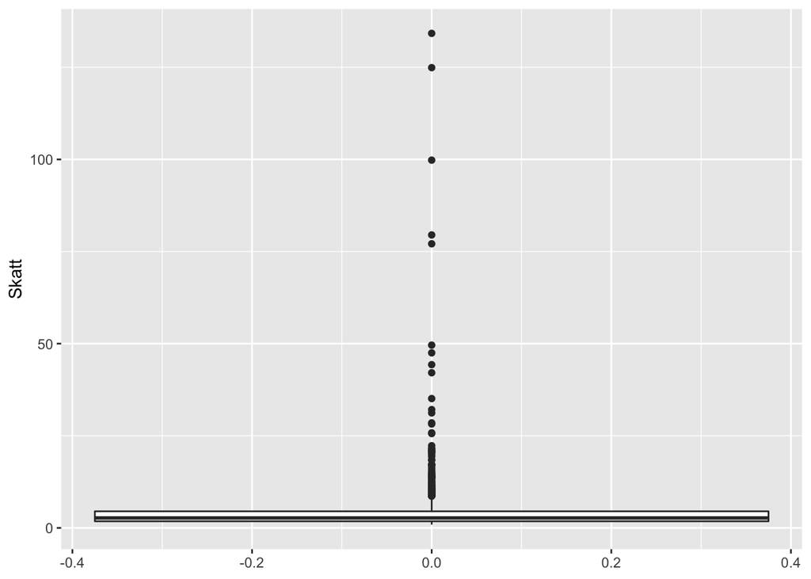

```r
ggplot(rikeste1000) + geom_boxplot(mapping = aes(y = Skatt))
```

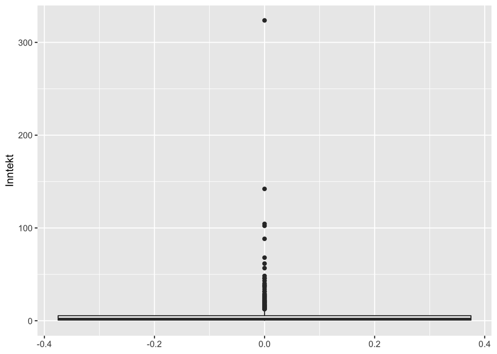

```r
ggplot(rikeste1000) + geom_boxplot(mapping = aes(y = Inntekt))
```

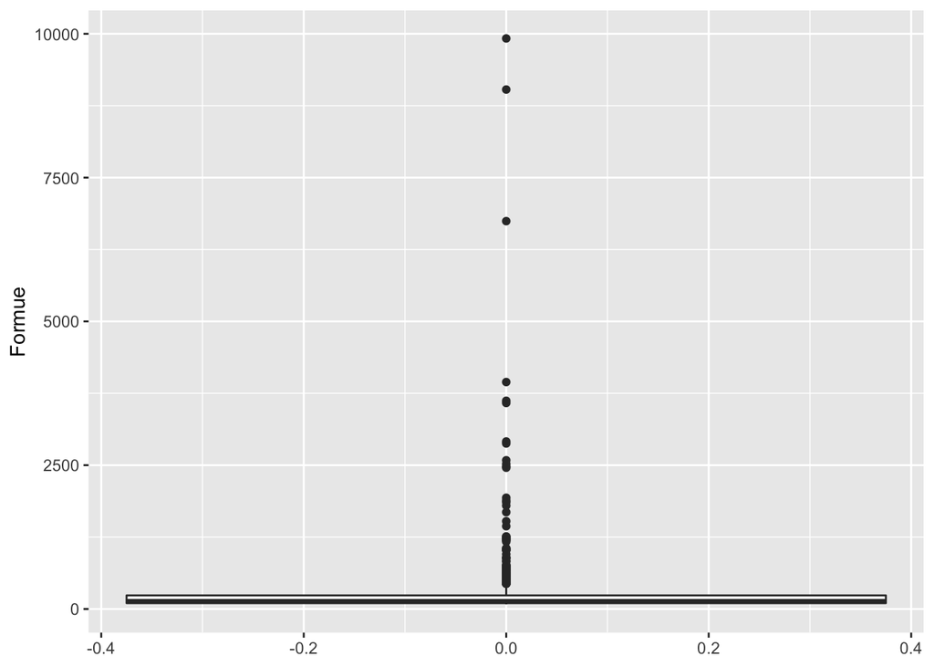

```r
ggplot(rikeste1000) + geom_boxplot(mapping = aes(y = Formue))
```

There are many outliers that generally falls in the higher values for the listed parameters. Without doing anything about these outliers, I checked whether there is any relationship between these parameters with using scatter plots. I also added a regression line with confidence intervals and Pearson correlation value. These plots show very high correlations between income and tax, and wealth and tax, and a low correlation between wealth and income. However, the correlations are obviously affected from the outlier points.

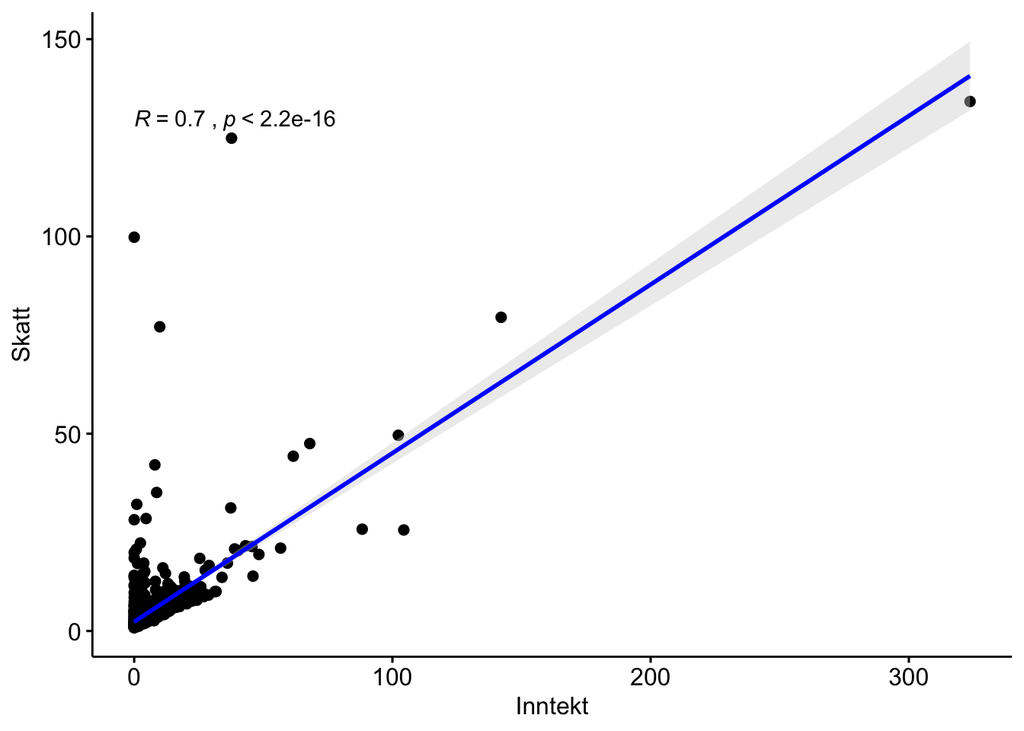

```r
ggscatter(data = rikeste1000, x = "Inntekt", y = "Skatt", add = "reg.line",
          add.params = list(color = "blue", fill = "lightgray"),
          conf.int = TRUE) + stat_cor(method = "pearson")
```

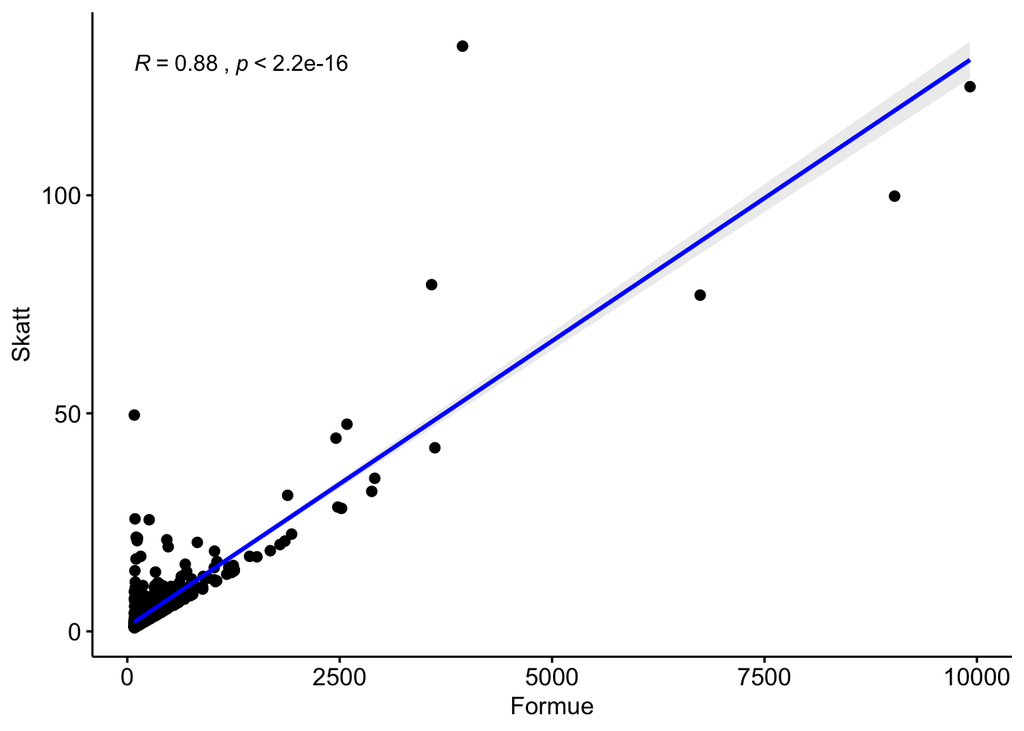

```r
ggscatter(data = rikeste1000, x = "Formue", y = "Skatt", add = "reg.line",
          add.params = list(color = "blue", fill = "lightgray"),
          conf.int = TRUE) + stat_cor(method = "pearson")
```

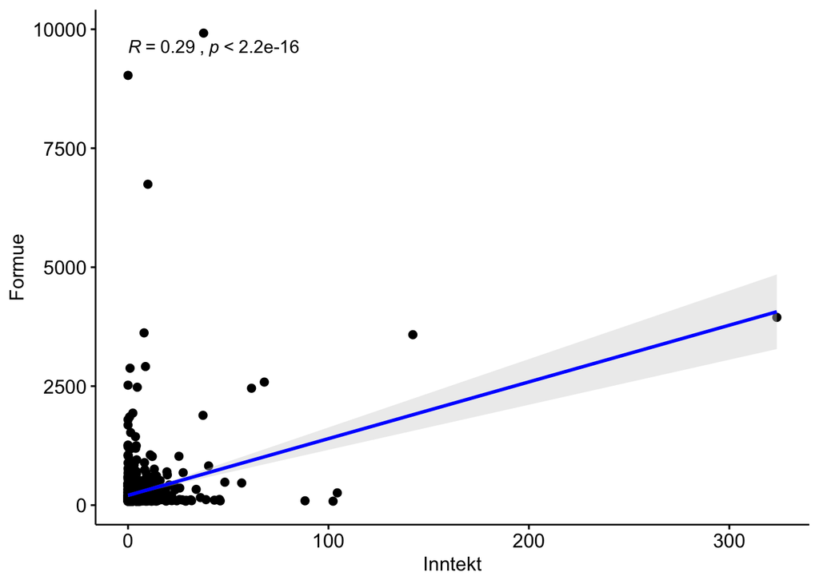

```r
ggscatter(data = rikeste1000, x = "Inntekt", y = "Formue", add = "reg.line",
          add.params = list(color = "blue", fill = "lightgray"),
          conf.int = TRUE) + stat_cor(method = "pearson")
```

I removed outlier points/people by using interquartile range in a function named outliers.

```r
outliers <- function(x){
  x > quantile(x)[4] + 1.5*IQR(x) | x < quantile(x)[2] - 1.5*IQR(x)
}

attach(rikeste1000)
outlier_inntekt <- sum(outliers(Inntekt))
outlier_inntekt_index <- which(outliers(Inntekt))
outlier_skatt <- sum(outliers(Skatt))
outlier_skatt_index <- which(outliers(Skatt))
outlier_formue <- sum(outliers(Formue))
outlier_formue_index <- which(outliers(Formue))

rikeste1000_orem <- slice(rikeste1000, -c(outlier_inntekt_index,outlier_skatt_index, outlier_formue_index))
```

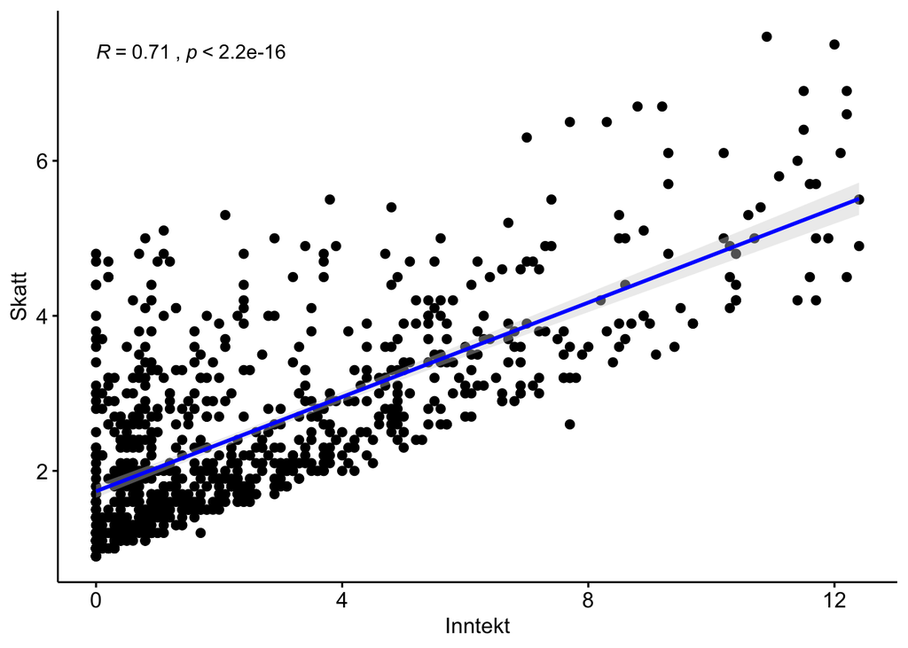

```r
ggscatter(data = rikeste1000_orem, x = "Inntekt", y = "Skatt", add = "reg.line",
          add.params = list(color = "blue", fill = "lightgray"),
          conf.int = TRUE) + stat_cor(method = "pearson")
```

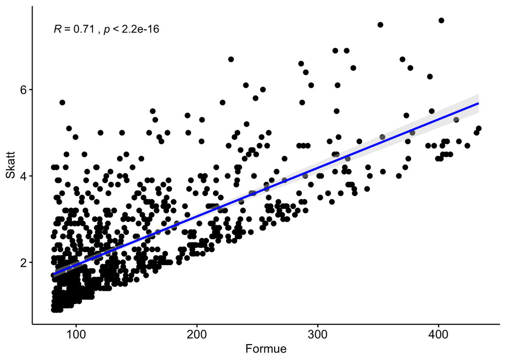

```r
ggscatter(data = rikeste1000_orem, x = "Formue", y = "Skatt", add = "reg.line",
          add.params = list(color = "blue", fill = "lightgray"),
          conf.int = TRUE) + stat_cor(method = "pearson")
```

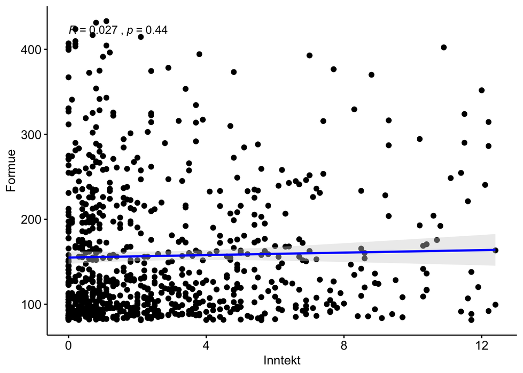

```r
ggscatter(data = rikeste1000_orem, x = "Inntekt", y = "Formue", add = "reg.line",
          add.params = list(color = "blue", fill = "lightgray"),
          conf.int = TRUE) + stat_cor(method = "pearson")
```

What else I can do with this data? 🤔. Maybe I can look into the birth year decades! I will use the original dataset for this part.

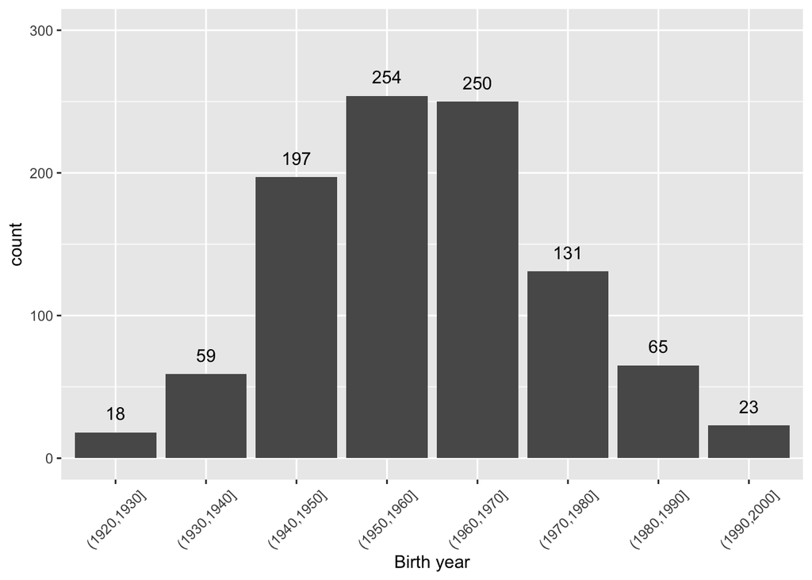

```r
rikeste1000 <- mutate(rikeste1000, FodtBin = cut(Fodt, breaks =seq(1920, 2000, 10), dig.lab=4)) # since I know minimum and maximum values from summary above
ggplot(rikeste1000, aes(x=FodtBin)) +
  geom_bar() +
  theme(axis.text.x = element_text(angle=45, vjust = 0.5)) + # to give an angle to x-axis labels
  xlab("Birth year") +
  ylim(NA, 300) + # to set the maximum of y-axis to make count values more visible
  geom_text(stat='count', aes(label=..count..), vjust=-1) # to add count values on top of bars
```

The last thing I want to look here is the places that these people were coming. There are 218 places on Bosted column. That’s too much for me. I will try to group these places into a different administrative unit in Norway: Fylke. First, I need another table:

```r
url <- "https://www.kartverket.no/Kunnskap/Fakta-om-Norge/Fylker-og-kommuner/Tabell/"
fylkeKommune <- htmltab(doc = url, which = "//table[@id='ctl00_FullRegion_UcTableDataGridView_DataTableGridView']") %>%
  rename(Bosted = "Kommunar (356)") %>% mutate(Bosted = toupper(Bosted))
newdf <- left_join(rikeste1000, fylkeKommune, by = "Bosted")
```

Now, I stuck here since there are 394 “Bosted”s that are smaller administrative units than I expected and I couldn’t find a source to map them into “Fylke” or “Kommune”. To be continued…